# team

Keven Lin & Adam Banwell

9/17/2021

```r
library("tidyverse")
library(classdata)
data(choco)
```

# Searching for the Best Chocolates

### 1. How are the cocoa percent distributed? Create both a histogram and a boxplot and describe them. Don’t forget to mention outliers, if there are any.

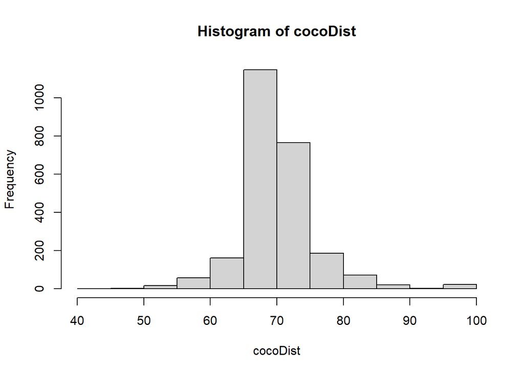

```r
cocoDist = choco$CocoaPercent
hist(cocoDist)
```

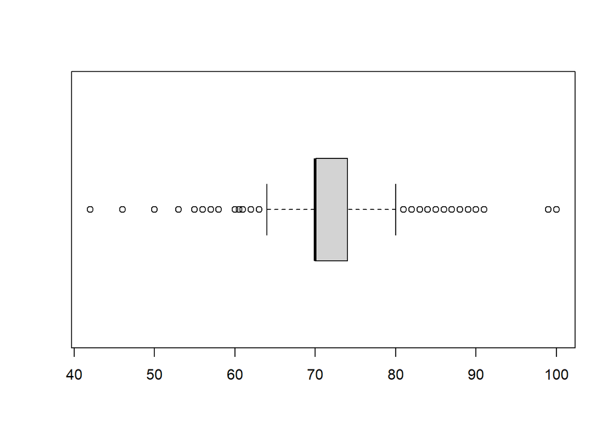

```r
boxplot(cocoDist, horizontal = TRUE)
```

For the histogram and box plot above, there are outliers clearly seen outside the whiskers of the box plot.The whiskers start at about 64% and end about 80% so all points below or above those points respectfully are considered outliers.